# Turkey Labor Force Statistics

Veli Kisa

27/04/2020

# Introduction

This data is downloaded from Turkish Statistical Institute website. (Link : http://www.turkstat.gov.tr/PreTabloArama.do?metod=search&araType=vt Labour Force Statistics (2014 and after)(M)) Data shows us the labour force statistics of Turkey. The number of labour force (thousand) is based on year (2014-2019) and there are sociological (gender, age_group,education) and regional variables. We can define these variables as;

gender= Erkek,Kadın (Male, Female)  
age_group= illustrates age ranges  
education=  
Okuma Yazma Bilmeyen = Unalphabet  
Lise Altı Eğitim = Lower High-School  
Lise ve Dengi Meslek Okulu = High School And Equivalent Technical High School  
Yüksek Öğretim = Higher Education  
regional =  
Akdeniz = Mediterrenean  
Batı Anadolu = Western Anatolia  
Batı Karadeniz = Western Black Sea  
Batı Marmara = Western Marmara  
Doğu Karadeniz= Eastern Karadeniz  
Doğu Marmara = Eastern Marmara  
Ege = Aegean  
Güneydoğu Anadolu = Southeastern Anatolia  
İstanbul = İstanbul  
Kuzeydoğu Anadolu= Northeastern Anatolia  
Orta Anadolu= Middle Anatolia  
Ortadoğu Anadolu = Middle Eastern Anatolia  
The numbers represent thousand result. We can specify the aim of this project as

*1. Loading and tidy data (Gathering and separating data)*  
2. Display some relations between exact variables.  
*3. Applying statistical tests to determine whether there is relation between variables.

# Loading and Tidy Data

```r
library(readxl)
veri <- read_excel("veri.xlsx")
```

Data need to be arranged

```r
library(tidyr)
colnames(veri)[3:14]<-gsub("-.*", "", colnames(veri)[3:14])
#remove all strings after "-" character
veri<-fill(veri,`cinsiyet_egitim.durumu`)
#fill null rows with the lastest full row
head(veri)
```

```
## # A tibble: 6 x 14
##   cinsiyet_egitim~ yil   Akdeniz `Batı Anadolu` `Batı Karadeniz`
##   <chr>            <chr>   <dbl> <chr>          <chr>
## 1 1. (15+) ve Erk~ 2014        2 0              0
## 2 1. (15+) ve Erk~ 2015        1 (6)*           (6)*
## 3 1. (15+) ve Erk~ 2016        1 1              0
## 4 1. (15+) ve Erk~ 2017        2 3              (6)*
## 5 1. (15+) ve Erk~ 2018        4 2              0
## 6 1. (15+) ve Erk~ 2019        2 0              1
## # ... with 9 more variables: `Batı Marmara` <chr>, `Doğu Karadeniz` <chr>,
## #   `Doğu Marmara` <chr>, Ege <chr>, `Güneydoğu Anadolu` <chr>,
## #   İstanbul <chr>, `Kuzeydoğu Anadolu` <chr>, `Orta Anadolu` <chr>,
## #   `Ortadoğu Anadolu` <chr>
```

Now we should separate the first column as “gender”, “age_group” and “education”

```r
library(stringr)
veri$cinsiyet_egitim.durumu<-str_replace_all(veri$'cinsiyet_egitim.durumu', "\\s", "")
#1 remove spaces
veri$cinsiyet_egitim.durumu<-str_split(veri$cinsiyet_egitim.durumu, "ve")
#2 split cells as specific string ("ve")
veri<-separate(veri,cinsiyet_egitim.durumu,c("gen_age","gender","age_group","education"),sep=',')
#3 separate cells to columns with column names
veri<-veri[,-1]
#4 remove unnecessary column
veri$age_group<-gsub(".*\\((.*)\\).*", "\\1", veri$age_group)
veri$education<-gsub(".*\\((.*)\\).*", "\\1", veri$education)
#5 take exact string into paranthesis
veri$gender<-str_replace_all(veri$gender, "[[:punct:]]", " ")
veri$education<-str_replace_all(veri$education, "[[:punct:]]", " ")
#6 remove any characteristic from cells
veri$gender<-str_replace_all(veri$gender, "\\s", "")
#7 take off the spaces
head(veri)
```

```
## # A tibble: 6 x 16
##   gender age_group education yil   Akdeniz `Batı Anadolu` `Batı Karadeniz`
##   <chr>  <chr>     <chr>     <chr>   <dbl> <chr>          <chr>
## 1 Erkek  15-19     "OkumaYa~ 2014        2 0              0
## 2 Erkek  15-19     "OkumaYa~ 2015        1 (6)*           (6)*
## 3 Erkek  15-19     "OkumaYa~ 2016        1 1              0
## 4 Erkek  15-19     "OkumaYa~ 2017        2 3              (6)*
## 5 Erkek  15-19     "OkumaYa~ 2018        4 2              0
## 6 Erkek  15-19     "OkumaYa~ 2019        2 0              1
## # ... with 9 more variables: `Batı Marmara` <chr>, `Doğu Karadeniz` <chr>,
## #   `Doğu Marmara` <chr>, Ege <chr>, `Güneydoğu Anadolu` <chr>,
## #   İstanbul <chr>, `Kuzeydoğu Anadolu` <chr>, `Orta Anadolu` <chr>,
## #   `Ortadoğu Anadolu` <chr>
```

To gather regions (from ‘Akdeniz’ to ‘Orta Doğu Anadolu’) into one column (format should be as ‘region’,‘gender’,‘education’,‘age_group’,‘year’,‘Observation(N)’) ,

```r
veri<-gather(veri, region, N, colnames(veri)[5:16])
veri<-veri[,c(5,1,3,2,4,6)]
colnames(veri)[5]<-"year"
head(veri)
```

```
## # A tibble: 6 x 6
##   region  gender education              age_group year  N
##   <chr>   <chr>  <chr>                  <chr>     <chr> <chr>
## 1 Akdeniz Erkek  "OkumaYazmaBilmeyen  " 15-19     2014  2
## 2 Akdeniz Erkek  "OkumaYazmaBilmeyen  " 15-19     2015  1
## 3 Akdeniz Erkek  "OkumaYazmaBilmeyen  " 15-19     2016  1
## 4 Akdeniz Erkek  "OkumaYazmaBilmeyen  " 15-19     2017  2
## 5 Akdeniz Erkek  "OkumaYazmaBilmeyen  " 15-19     2018  4
## 6 Akdeniz Erkek  "OkumaYazmaBilmeyen  " 15-19     2019  2
```

```r
str(veri)
```

```
## Classes 'tbl_df', 'tbl' and 'data.frame':    5760 obs. of  6 variables:
##  $ region   : chr  "Akdeniz" "Akdeniz" "Akdeniz" "Akdeniz" ...
##  $ gender   : chr  "Erkek" "Erkek" "Erkek" "Erkek" ...
##  $ education: chr  "OkumaYazmaBilmeyen  " "OkumaYazmaBilmeyen  " "OkumaYazmaBilmeyen  " "OkumaYazmaBilmeyen  " ...
##  $ age_group: chr  "15-19" "15-19" "15-19" "15-19" ...
##  $ year     : chr  "2014" "2015" "2016" "2017" ...
##  $ N        : chr  "2" "1" "1" "2" ...
```

Before analysing, column types should be assigned correctly.

```r
library(lubridate)
veri$region<-as.factor(veri$region)
veri$gender<-as.factor(veri$gender)
veri$education<-as.factor(veri$education)
veri$age_group<-as.factor(veri$age_group)
veri$year<-lubridate::year(as.Date(veri$year,format= "%Y"))
veri$N<-as.numeric(veri$N)
str(veri)
```

```
## Classes 'tbl_df', 'tbl' and 'data.frame':    5760 obs. of  6 variables:
##  $ region   : Factor w/ 12 levels "Akdeniz","Batı Anadolu",..: 1 1 1 1 1 1 1 1 1 1 ...
##  $ gender   : Factor w/ 2 levels "Erkek","Kadın": 1 1 1 1 1 1 1 1 1 1 ...
##  $ education: Factor w/ 4 levels "LiseAltıEğitimliler  ",..: 3 3 3 3 3 3 1 1 1 1 ...
##  $ age_group: Factor w/ 5 levels "15-19","20-24",..: 1 1 1 1 1 1 1 1 1 1 ...
##  $ year     : num  2014 2015 2016 2017 2018 ...
##  $ N        : num  2 1 1 2 4 2 134 130 140 142 ...
```

# Visualisation of Data

Before plotting the graphs we need to create the frequency tables of variables that we want to plot. Variables “gender”, “education” and “age_group” will be tabulated based on years.

```r
library(plyr)
library(dplyr)
vars <- names(veri)[2:4]
for (i in vars) {
  print(i)
  freq.table <- veri %>% group_by_("year",i)%>%dplyr::summarise(sum. = sum(N,na.rm = T))
  freq.table<-ddply(freq.table, .(year), mutate, per. = round((sum. / sum(sum.,na.rm = T)),3))
  print(freq.table)
}
```

```
## [1] "gender"
```

```
##    year gender  sum.  per.
## 1  2014  Erkek 39588 0.696
## 2  2014  Kadın 17267 0.304
## 3  2015  Erkek 40361 0.689
## 4  2015  Kadın 18244 0.311
## 5  2016  Erkek 41227 0.684
## 6  2016  Kadın 19067 0.316
## 7  2017  Erkek 42342 0.678
## 8  2017  Kadın 20108 0.322
## 9  2018  Erkek 42939 0.675
## 10 2018  Kadın 20701 0.325
## 11 2019  Erkek 43051 0.671
## 12 2019  Kadın 21142 0.329
## [1] "education"
##    year                education  sum.  per.
```

[output cut: 56 more lines]

Following chunk indicates the barplot graphs of work force numbers according to gender, education and age_group variables for certain years.

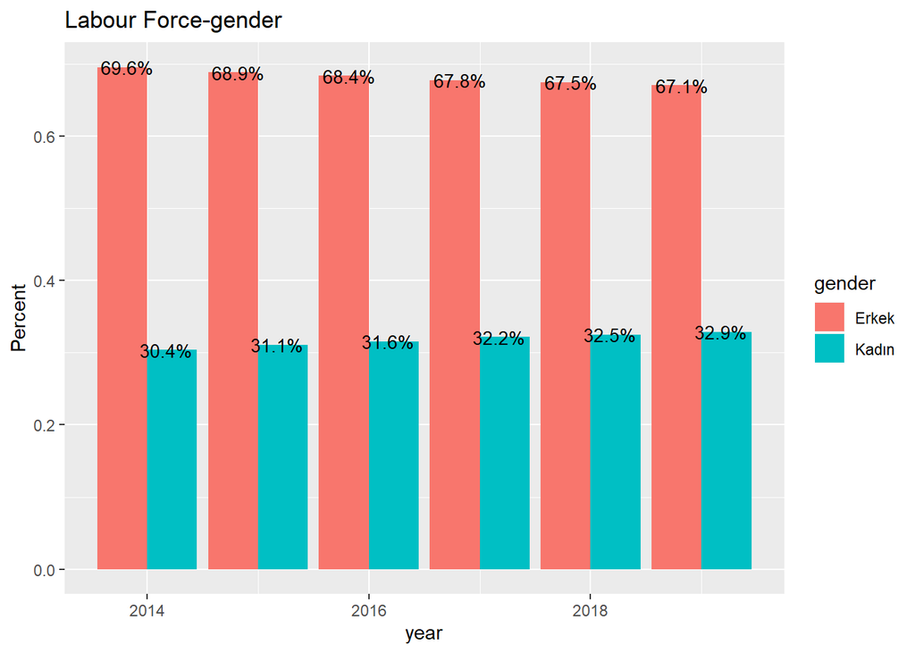

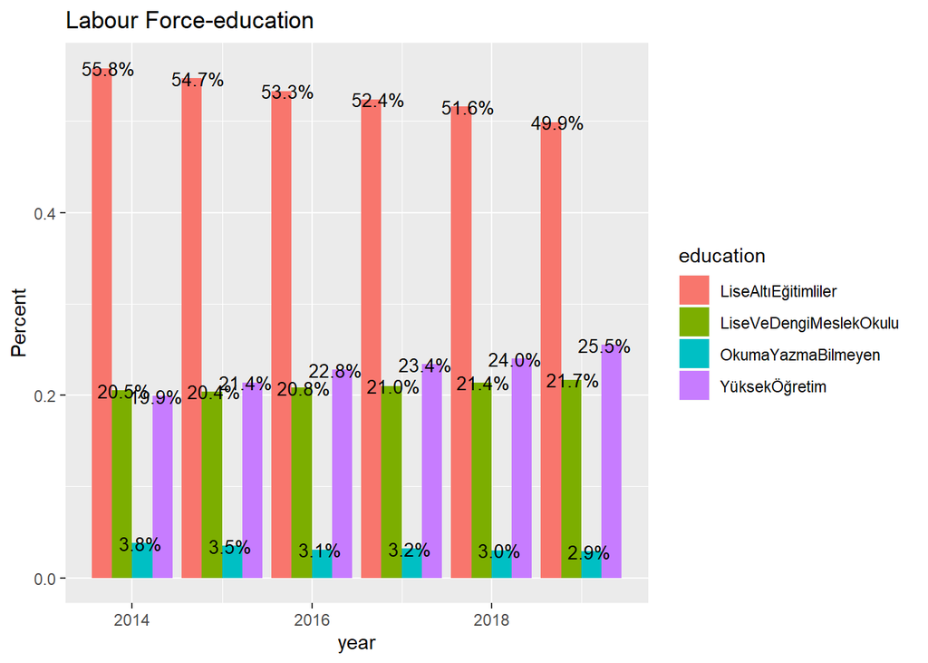

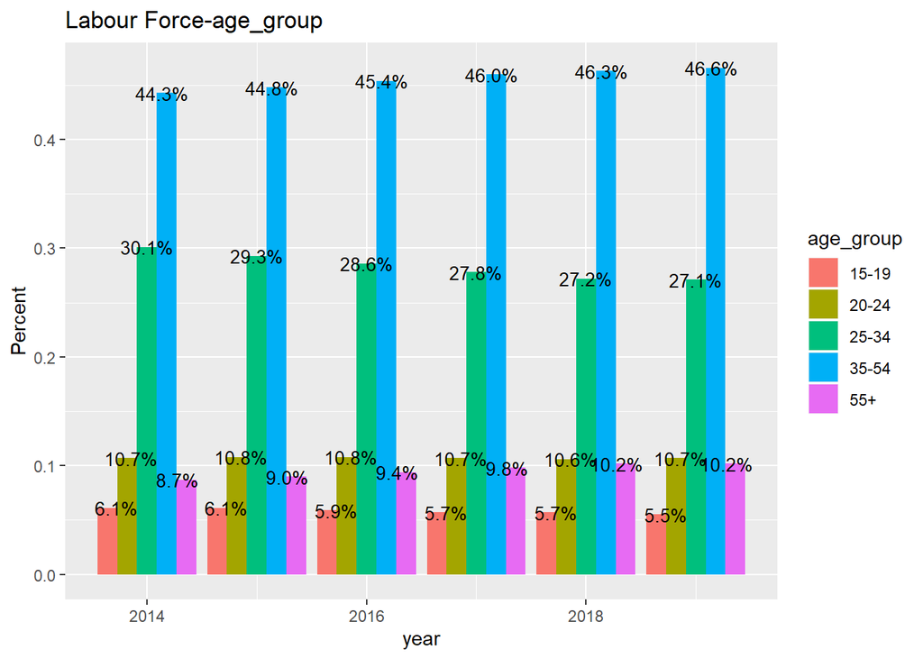

```r
library(ggplot2)
for (i in vars) {

  freq.table <- veri %>% group_by_("year",i)%>%dplyr::summarise(sum. = sum(N,na.rm = T))
  freq.table<-ddply(freq.table, .(year), mutate, per. = round((sum. / sum(sum.,na.rm = T)),3))

  p<-ggplot(freq.table,aes(fill=freq.table[,i],y=freq.table[,"per."],x=freq.table[,"year"]))+
    geom_bar(position="dodge", stat="identity")+
    geom_text(aes(label=scales::percent(freq.table$per.)),position = position_dodge(.7),
              size=3.5)+
    labs(title=paste("Labour Force",i,sep = "-"),y="Percent",x="year",fill=i)
  print(p)
}
```

# Building Predictive Model

Choosing the best suited technique based on type of predictors and target variable, dimensionality in the data. To select the right regression model belows are key factors on that way; * Data exploration (We have already done on previous sections.) * To compare the goodness of fit for different models, we can analyse with different metrics such as R-square, adjusted R-square, AIC, BIC, significance of parameters and error term. * And last but not least technique is definitely CV (Cross-Validation). This technique is the best way to evaluate models used for prediction. In this technique we need to divide our data set into two group (train and test). A simple mean squared difference between the observed and predicted values give us a measure for the prediction accuracy.

Now, to select the right regression model we will apply both techniques (comparing the GOF and CV).

## Comparing the Goodness of Fit Values

To investigate the relationship “gender” , “age_group” , “education” with labor force , we need to apply statistical tests. While these three variables are independent as well as categoric, labor force (N) variable is target (dependent) and numeric. In this part the target variable will be considered as continuous. (We don’t choose integer because range is much.)

To select best features and create model “MXM” is a usefull package in R library. Get more information :https://arxiv.org/pdf/1611.03227.pdf

### Continuous Target- Mixed Predictors

“test” input describes the conditional independence test to use. Continuous(Target)- Mixed (predictors)= testIndReg (Linear regression) “max_k” implies the maximum conditioning set to use in the conditional independence test. “threshold” shows the threshold (suitable values in [0,1]) for assessing p-values significance. Default value is 0.05.

```r
library(MXM)
veri_na<-veri[-which(is.na(veri$N)),]
veri_target<-veri_na$N
veri_na2<-as.data.frame(veri_na[,-c(5,6)])
result1<- MXM::SES(target = veri_target,dataset = veri_na2,threshold = 0.1,max_k = 4,
                   test = "testIndReg",ini= NULL,wei= NULL,user_test= NULL,
                   hash       = TRUE, hashObject = NULL,ncores = 1 )
result1@selectedVars
```

```
## [1] 1 2 3 4
```

```r
result1@selectedVarsOrder
```

```
## [1] 4 3 1 2
```

```r
result1@stats
```

```
## [1]  69.80676 251.86813 341.32139 282.10034
```

```r
result1@pvalues
```

```
## [1] -337.2629 -126.1268 -466.6160 -507.3339
```

```r
result1@univ
```

```
## $stat
## [1]  69.80676 251.86813 341.32139 282.10034
##
## $pvalue
## [1] -337.2629 -126.1268 -466.6160 -507.3339
```

First display means that four all predictors (region,gender,education, age_group) seleceted as variable for model and second output sorts these variables as significance values. 3rd and 4th results are about association degree between predictors and target variable. (while lower p-values indicate higher association, in test statistics (stats) , higher values indicate higher relation). We can explain such that “age_group”,“education”, “region” and “gender” become predictors for our model in order of importance.

##Creating the Model and Cross Validation Test

Now, we can create a model with selected variable. We apply the linear regression and negative binomial regression. In this chapter we need to “caret” and “MASS” package to use these methods. We will also use Cross validation to evaluate models used for prediction. So we will split the data in training and test data.

```r
library(dplyr)
library(caret)
tra.samples<-veri_na$N %>%
  createDataPartition(p=0.8, list = FALSE)
tra.data<-veri_na[tra.samples,-5]
test.data<-veri_na[-tra.samples,-5]
model.lm <- lm(N ~., data = tra.data)
predictions.lm <- model.lm %>% predict(test.data)
data.frame( R2 = R2(predictions.lm, test.data$N),
            RMSE = RMSE(predictions.lm, test.data$N),
            MAE = MAE(predictions.lm, test.data$N))
```

```
##          R2     RMSE      MAE
## 1 0.5232929 78.10411 48.35421
```

Because the mean and variance of our target variable is not equal and categorical predictors- continuous (integer actually), we are appliying the neg. binomial regression. Negative binomial regression can be used for over-dispersed count data, that is when the conditional variance exceeds the conditional mean.

```r
library(MASS)
tra.samples2<-veri_na$N %>%
  createDataPartition(p=0.8, list = FALSE)
tra.data2<-veri_na[tra.samples2,-5]
test.data2<-veri_na[-tra.samples2,-5]
model.nb <- glm.nb(N ~., data = tra.data2)
predictions.nb <- model.nb%>% predict(test.data2)
data.frame( R2 = R2(predictions.nb, test.data2$N),
            RMSE = RMSE(predictions.nb, test.data2$N),
            MAE = MAE(predictions.nb, test.data2$N))
```

```
##          R2     RMSE      MAE
## 1 0.4639468 116.8243 60.41091
```

When comparing two models linear and negative binom regressions, the one that produces the *lowest test sample RMSE* is the preferred model. So we can say that the linear model can be preferred than negative binomial regression.

# Conclusion

In this project we have aimed to select related independent variables and set up models. After modelling we did compare these models and picked the more appropiate model.

For the future projects , converting the categoric variables to numerical using dummy variables can be good idea. So there could be more useful and comparable models we can use.